# Model selection and validation

Joshua Loftus

#### Outline

- Comparing two nested models with the $F$-test
- Optimization and model selection algorithms
- Overfitting, model complexity, bias-variance tradeoff
- Validation and cross-validation

## The $F$-test for nested models

- A method that uses hypothesis tests to compare linear models
- The models must be nested: the larger of the two models contains all of the predictor variables in the smaller one, plus some extra variables
- Motivating question: do we really need this larger model, or would the smaller, simpler one be sufficient?
- Larger model, often called the “full” model, with $p$ predictors:
  $$y_i = \beta_0 + \beta_1 x_{i1} + \beta_2 x_{i2} + \cdots + \beta_q x_{ik} + \cdots + \beta_p x_{ip} + e_i$$
- Simpler model, often called the “sub” model, with $k < p$ predictors:
  $$y_i = \beta_0 + \beta_1 x_{i1} + \beta_2 x_{i2} + \cdots + \beta_q x_{ik} + e_i$$
- The sub-model omits variables $k+1, k+2, \ldots, p$
- (We can always rearrange the variables, so it doesn’t matter if we’re leaving out the first, last, or variables in the middle)

```r
full_model <- lm(winpercent ~ chocolate +
             fruity + caramel + hard + bar +
             sugarpercent + pricepercent,
           data = candy_rankings)
sub_model <- lm(winpercent ~ chocolate + sugarpercent,
           data = candy_rankings)
chocolate_model <- lm(winpercent ~ chocolate, data = candy_rankings)
tidy(full_model)
```

```
##            term  estimate std.error  statistic      p.value
## 1   (Intercept) 34.849651  3.995614  8.7219761 4.121255e-13
## 2 chocolateTRUE 21.222221  4.004069  5.3001635 1.069829e-06
## 3    fruityTRUE  7.563380  3.828542  1.9755248 5.179194e-02
## 4   caramelTRUE  1.829913  3.614236  0.5063069 6.140878e-01
## 5      hardTRUE -6.389220  3.496633 -1.8272494 7.153689e-02
## 6       barTRUE  3.001409  3.766306  0.7969105 4.279534e-01
## 7  sugarpercent  9.396004  4.734918  1.9844066 5.077349e-02
## 8  pricepercent -3.337411  5.516023 -0.6050393 5.469319e-01
```

```r
tidy(sub_model)
```

```
##            term estimate std.error statistic      p.value
## 1   (Intercept) 38.26211  2.552430 14.990465 3.308889e-25
## 2 chocolateTRUE 18.27331  2.468991  7.401124 1.058930e-10
## 3  sugarpercent  8.56662  4.354581  1.967266 5.253395e-02
```

```r
rbind(glance(full_model), glance(sub_model))
```

```
##   r.squared adj.r.squared    sigma statistic      p.value df    logLik
## 1 0.4785593     0.4311556 11.09783  10.09540 6.800303e-09  8 -320.9825
## 2 0.4319631     0.4181085 11.22438  31.17841 8.500396e-11  3 -324.6201
##        AIC      BIC  deviance df.residual
## 1 659.9651 681.9489  9483.461          77
## 2 657.2403 667.0109 10330.907          82
```

- How could we compare and choose between these models?
- (Could compare residual standard error or adjusted R-squared)

### Hypothesis testing approach

- We may be interested in choosing between the models using a hypothesis test, e.g. for scientific purposes
- The null hypothesis is that the smaller, simpler model is good enough
- The alternative hypothesis is that **at least one** of the additional variables in the larger model provides a significant improvement
- The residual sum of squares (**RSS**) is
  $$\sum_{i=1}^n (y_i - \hat y_i)^2$$
- Let’s write $RSS_f$ for the residual sum of squares when predictions $\hat y$ are given by the full model, and $RSS_s$ for the sub model
- Note: $RSS_f \leq RSS_s$
- The $F$ statistic for comparing these two models is
  $$F = \frac{\left(\frac{RSS_s - RSS_f}{p - k}\right)}{\left(\frac{RSS_f}{n-p}\right)}$$
- The observed value is compared to an $F_{p-k, n - p}$ distribution to find a $p$-value
- In `R`, after fitting both models, use the `anova()` function on them like this:

```r
anova(sub_model, full_model)
```

```
## Analysis of Variance Table
##
## Model 1: winpercent ~ chocolate + sugarpercent
## Model 2: winpercent ~ chocolate + fruity + caramel + hard + bar + sugarpercent +
##     pricepercent
##   Res.Df     RSS Df Sum of Sq      F Pr(>F)
## 1     82 10330.9
## 2     77  9483.5  5    847.45 1.3762 0.2426
```

- Advantage: hypothesis test framing may be a natural way to answer the scientific or practical question that the regression models are being used to study
- Disadvantage: only for nested models, maybe hypothesis testing isn’t relevant and we just want the “best” model

## Optimization and model selection algorithms

- Optimization is an area of math that develops and analyzes methods for finding maximums or minimums of functions
- [Much of it](https://en.wikipedia.org/wiki/Newton%27s_method) is based on calculus, but [not all](https://en.wikipedia.org/wiki/Bisection_method)
- (It’s extremely useful and one of the common prereqs for many of the most successful researchers or users of machine learning / AI / or even statistics. Along with linear algebra, if you have the chance to study optimization and it aligns with your goals I strongly recommend it)
- We have already thought of linear regression as an optimization problem: find the best line (or plane/hyperplane for multiple regression), where best means smallest sum of squared errors

$$\text{minimize}_{\beta_0, \beta_1} \sum_{i=1}^n (y_i - \beta_0 - \beta_1 x_i)^2$$

- This notation means to pick the parameters $\beta_0$ and $\beta_1$ to minimize the sum of squared errors
- The sample mean can also be thought of as the solution to an optimization problem: find the best constant to minimize the squared errors

$$\text{minimize}_{\beta_0} \sum_{i=1}^n (y_i - \beta_0)^2$$

- Many methods in statistics and machine learning can be described as optimization problems, with possibly more complicated kinds of functions

$$\text{minimize}_{f} \sum_{i=1}^n (y_i - f(x_i))^2$$

- The resulting model predicts $y$ using the function $f(x)$:

$$y_i = f(x_i) + e_i$$

- So far we have used a linear function: $f(x) = \beta_0 + \beta_1 x$
- A method that has recently become very popular, deep learning, constructs complicated non-linear functions by composing many “layers” of simple non-linear functions

$$\text{minimize}_{f_1, f_2, f_3} \sum_{i=1}^n (y_i - f_3[f_2(f_1[x_i])])^2$$
- (If you compose linear functions, the resulting function is also linear, just with different coefficients) - (If you compose simple non-linear functions, the resulting function can be a very complicated non-linear one)

- The issues we talk about today are not just issues with linear models, but with all kinds of similar methods in stats/ML/data science/AI
- Common elements: data, modeling assumptions about what kinds of functions are reasonable, and algorithms to find a function in that class that “best” fits the data
- Whenever we’re trying to get the “best” of something, there is a danger of overfitting…

### Model selection algorithms

- Suppose there are multiple predictor variables, possibly many of them, and we don’t know which ones to include in the linear model
- How about letting the computer pick them for us?
- General definition: models with more variables are considered more complex

### Create a sequence of models with increasing complexity

- General idea: start with no variables and add one at a time, each time picking the “best” out of the remaining predictors
- Special cases of this idea, each with a different definition of “best” for the next variable to add: forward stepwise, lasso, elastic net, and others
- Now we just have to pick one model out of a (possibly small) list of models

### Penalize complexity

- Increasing complexity will make the model fit closer and closer to the data, reducing the RSS
- It’s never impressive to make a model fit more closely to data unless there are some other constraints on the model that make it useful
- Common approach: penalize complexity. Instead of just trying to minimize RSS (fit) by itself, try to minimize
  $$\text{fit error} + \text{complexity}$$
- Typically the fit error is measured by RSS and the complexity is quantified in some way related to the number of variables in the model
- For example, one method, called AIC, is to pick the model with the lowest
  $$n\log(RSS) + 2k$$
  where $k$ is the number of variables in the model.
- This code below shows output for a sequence of models. At the end is a summary of the model chosen by the AIC method.

```r
candy <- candy_rankings %>% select(-competitorname)
full_model <- lm(winpercent ~ ., data = candy)
const_model <- lm(winpercent ~ 1, data = candy)
selected_model <- step(const_model,
     scope = list(lower = const_model, upper = full_model),
     direction = "forward")
```

```
## Start:  AIC=458.09
## winpercent ~ 1
##
##                    Df Sum of Sq   RSS    AIC
## + chocolate         1    7368.5 10818 415.94
## + bar               1    3361.7 14825 442.72
## + peanutyalmondy    1    3000.7 15186 444.77
## + fruity            1    2639.2 15548 446.77
## + pricepercent      1    2168.8 16018 449.30
## + crispedricewafer  1    1917.2 16270 450.63
## + hard              1    1752.1 16435 451.48
## + pluribus          1    1113.6 17073 454.72
## + sugarpercent      1     955.0 17232 455.51
## + caramel           1     828.4 17359 456.13
## + nougat            1     722.9 17464 456.65
## <none>                          18187 458.09
##
## Step:  AIC=415.94
## winpercent ~ chocolate
##
##                    Df Sum of Sq   RSS    AIC
## + peanutyalmondy    1    582.51 10236 413.24
## + sugarpercent      1    487.59 10331 414.02
## + fruity            1    336.12 10482 415.26
## <none>                          10818 415.94
## + crispedricewafer  1    237.84 10581 416.05
## + hard              1    172.00 10646 416.58
## + bar               1     69.75 10749 417.39
## + caramel           1     57.34 10761 417.49
## + nougat            1     26.82 10792 417.73
## + pluribus          1     20.06 10798 417.78
## + pricepercent      1     14.16 10804 417.83
##
## Step:  AIC=413.24
## winpercent ~ chocolate + peanutyalmondy
##
##                    Df Sum of Sq     RSS    AIC
## + fruity            1    547.28  9688.7 410.57
## + sugarpercent      1    434.23  9801.7 411.55
## + crispedricewafer  1    390.81  9845.2 411.93
```

[output cut: 44 more lines]

```
## + nougat        1     41.81 8870.9 409.07
## + bar           1     11.39 8901.3 409.36
## + pluribus      1      6.61 8906.1 409.41
##
## Step:  AIC=406.29
## winpercent ~ chocolate + peanutyalmondy + fruity + crispedricewafer +
##     sugarpercent + hard
##
##                Df Sum of Sq    RSS    AIC
## <none>                      8585.7 406.29
## + pricepercent  1   125.077 8460.6 407.04
## + caramel       1    61.164 8524.5 407.68
## + nougat        1    31.646 8554.0 407.98
## + pluribus      1    30.632 8555.0 407.99
## + bar           1     6.049 8579.6 408.23
```

```r
summary(selected_model)
```

```
##
## Call:
## lm(formula = winpercent ~ chocolate + peanutyalmondy + fruity +
##     crispedricewafer + sugarpercent + hard, data = candy)
##
## Residuals:
##      Min       1Q   Median       3Q      Max
## -21.5030  -6.7026   0.5668   5.8802  24.0107
##
## Coefficients:
##                      Estimate Std. Error t value Pr(>|t|)
## (Intercept)            32.941      3.518   9.365 2.12e-14 ***
## chocolateTRUE          19.147      3.587   5.338 8.98e-07 ***
## peanutyalmondyTRUE      9.483      3.446   2.752  0.00737 **
## fruityTRUE              8.881      3.561   2.494  0.01473 *
## crispedricewaferTRUE    8.385      4.484   1.870  0.06525 .
## sugarpercent            7.979      4.129   1.932  0.05693 .
## hardTRUE               -5.669      3.289  -1.724  0.08871 .
## ---
## Signif. codes:  0 '***' 0.001 '**' 0.01 '*' 0.05 '.' 0.1 ' ' 1
##
## Residual standard error: 10.49 on 78 degrees of freedom
## Multiple R-squared:  0.5279, Adjusted R-squared:  0.4916
## F-statistic: 14.54 on 6 and 78 DF,  p-value: 4.622e-11
```

- Check: is the adjusted R-squared for this model better than the one for `sub_model` back near the top of these notes? How much better?

```r
rbind(glance(selected_model), glance(sub_model))
```

```
##   r.squared adj.r.squared    sigma statistic      p.value df    logLik
## 1 0.5279241     0.4916106 10.49155  14.53794 4.621890e-11  7 -316.7557
## 2 0.4319631     0.4181085 11.22438  31.17841 8.500396e-11  3 -324.6201
##        AIC      BIC  deviance df.residual
## 1 649.5113 669.0525  8585.661          78
## 2 657.2403 667.0109 10330.907          82
```

## Overfitting, model complexity, bias-variance tradeoff

- In general, models with greater complexity will have lower bias, but higher variance in their predictions
- See the last plot near the bottom of [this page](http://scott.fortmann-roe.com/docs/BiasVariance.html)
- Example: for a single non-linear relationship (instead of having multiple variables), the degree of nonlinearity is a measure of complexity
- A more “wiggly” curve comes from a more complex model–it can wiggle around to get closer to points in the data, making it less biased but with more variance
- The dashed line below has higher complexity (more variance, less bias)

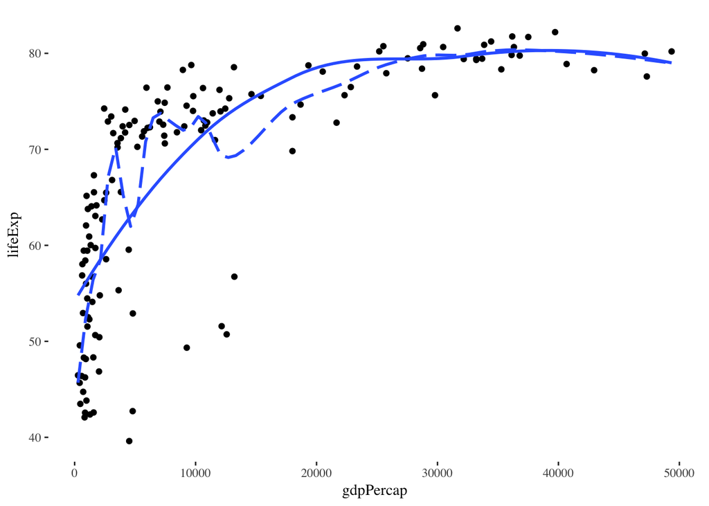

```r
gm2007 <- gapminder %>% filter(year == "2007")
ggplot(gm2007, aes(gdpPercap, lifeExp)) + geom_point() +
  stat_smooth(se = F, method = "loess", span = 1) +
  stat_smooth(se = F, method = "loess", span = 0.2, linetype = 5)
```

### What if we don’t know how to penalize complexity?

- In a previous example, we used a method called AIC which is a measure of how good the model is that penalizes how many variables it has
- But what if we aren’t using a linear model, but some other machine learning method where there is no classical statistical theory developing an analogous version of the AIC?
- There is a general method called validation that works for almost every kind of model
- First, we’ll go into more detail about why too much complexity is bad

## Overfitting

- [Google flu trends](https://gking.harvard.edu/files/gking/files/0314policyforumff.pdf)
- [Spurious correlations](http://www.tylervigen.com/spurious-correlations)
- [History example](https://xkcd.com/1122/)
- [Math example](https://i.stack.imgur.com/2AUPV.jpg)
- In our previous example, model complexity was measured using the number of predictor variables
- But it may not always be easy to figure out how to measure or penalize model complexity, so it would be nice to have a more general method to avoid overfitting
- Validation and cross-validation are very general, practical, popular, and especially appropriate if there is a large sample of data

## Validation

- Split the data into two sets: a **training** set and a **test** set
- Use optimization on the training set to fit models
- Measure the accuracy of fitted models on the test set
- Plot this test accuracy or test error rate as a function of model complexity
- Choose complexity that gives the best test error
- In this example I create a fake data set (simulation) with sample size $n = 300$ and $p = 100$ predictor variables. The outcome variable $y_i = x_{i1} + x_{i2} + x_{i3} + e_i$ only depends on the first 3 out of the 100 predictors.

```r
n <- 300
p <- 100
beta <- c(rep(1, 3), rep(0, p - 3))
X <- matrix(rnorm(n*p), nrow = n)
y <- X %*% beta + rnorm(n)
data <- data.frame(y = y, X = X)
```

- Split the data:

```r
train <- data %>% sample_frac(0.5)
test <- setdiff(data, train)
```

- Fit models on training data

```r
simple_model <- lm(y ~ X.1 + X.2 + X.3, data = train)
full_model <- lm(y ~ ., data = train) # the . means "every variable in the data"
rbind(glance(simple_model), glance(full_model))
```

```
##   r.squared adj.r.squared     sigma  statistic      p.value  df    logLik
## 1 0.7882191     0.7838674 0.9699262 181.130554 5.311113e-49   4 -206.2333
## 2 0.9334304     0.7975742 0.9386669   6.870722 1.197464e-11 101 -119.4355
##        AIC      BIC  deviance df.residual
## 1 422.4667 437.5199 137.35051         146
## 2 442.8709 749.9557  43.17368          49
```

- Which model is better, the one with 3 predictors or the one with 100 predictors *including* those 3?
- Evaluate models on the test data:

```r
errors <- data.frame(
  model = c(rep("simple", n/2), rep("full", n/2)),
  test_error = c((predict(simple_model, newdata = test) - test$y)^2,
                 (predict(full_model, newdata = test) - test$y)^2))

errors %>% group_by(model) %>% summarize(
  median = median(test_error),
  mean = mean(test_error)
)
```

```
## # A tibble: 2 x 3
##   model  median  mean
##   <fct>   <dbl> <dbl>
## 1 full    1.23  2.87
## 2 simple  0.458 0.914
```

- This was kind of cheating, because I knew the first 3 variables were the right ones to use in the simple model
- What if we don’t know that? Can we use a model selection algorithm to pick the right variables?

## Cross-validation

- Split the data into $K$ sets, often $K = 5$ or 10, for example.
- Use one of the sets as a test set, fitting models on the remaining $K-1$ sets and measuring their accuracy on this test set
- Repeat the above for each of the $K$ sets
- There are now $K$ measurements of accuracy for each model
- Average these $K$ measurements
- Plot this average as a function of model complexity
- The code below uses the `glmnet` library, which has a function to use cross-validation to pick variables automatically using a method called the lasso

```r
x_train <- as.matrix(train[,-1])
y_train <- train[,1]
x_test <- as.matrix(test[,-1])
y_test <- test[,1]
model <- cv.glmnet(x = x_train, y = y_train, nfolds = 5)
```

- Let’s look at a plot of the cross-validation model accuracy as a function of complexity

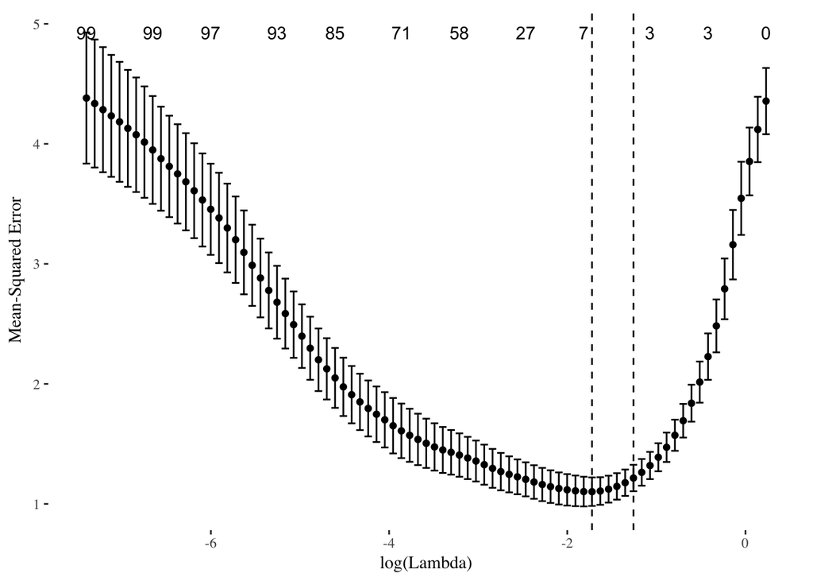

```r
autoplot(model)
```

- What are the fitted coefficients of the best model?

```r
coef(model)
```

```
## 101 x 1 sparse Matrix of class "dgCMatrix"
##                     1
## (Intercept) 0.0680559
## X.1         0.7057829
## X.2         0.6983142
## X.3         0.8568229
## X.4         .
## X.5         .
## X.6         .
## X.7         .
## X.8         .
## X.9         .
## X.10        .
## X.11        .
## X.12        .
## X.13        .
## X.14        .
## X.15        .
## X.16        .
## X.17        .
## X.18        .
## X.19        .
## X.20        .
## X.21        .
## X.22        .
## X.23        .
## X.24        .
## X.25        .
## X.26        .
## X.27        .
## X.28        .
## X.29        .
## X.30        .
## X.31        .
## X.32        .
## X.33        .
## X.34        .
## X.35        .
## X.36        .
## X.37        .
```

[output cut: 48 more lines]

```
## X.86        .
## X.87        .
## X.88        .
## X.89        .
## X.90        .
## X.91        .
## X.92        .
## X.93        .
## X.94        .
## X.95        .
## X.96        .
## X.97        .
## X.98        .
## X.99        .
## X.100       .
```

- Cross-validation and the lasso found the right variables to include in the model! Only the first 3, and the rest of the variables are not included
- As we saw before, the model using only the first three variables has better test error than the model which uses all 100 variables

### Summary

- Many cutting edge methods in ML/AI rely on optimization, just like linear regression
- More complex models have more parameters and/or more complex types of functions to predict the outcome variable
- Too much model complexity can lead to overfitting–for example, including too many predictor variables can make it seem like the model does a better job of prediction…
- Test or validation prediction accuracy is a higher standard
- Keep [this image](https://qph.fs.quoracdn.net/main-qimg-17ec84ff3f63f77f6b368f0eb6ef1890) in mind, and remember bias-variance tradeoff
- Cross-validation is a very useful method (when the sample size is large enough) to automatically pick models with low test error